# Optimal Sensor Placement for Modal Analysis

**LADPackage Demo: Optimal Sensor Placement**

This notebook demonstrates optimal sensor placement methods for structural health monitoring using modal analysis. The example compares two optimization approaches:

1. **Fisher Information Method**: Maximizes determinant of Fisher Information Matrix using Effective Independence algorithm
2. **Maximum Norm Method**: Maximizes weighted norm of modal responses with distance constraints

Both methods determine optimal locations for 12 sensors on a structural system to maximize modal observability.

**Reference**: Auto-Generated Script by mFUSE (3/19/2016)  
**Authors**: Eric Flynn, Dustin Harvey

**Educational Goals**:

- Understand sensor placement optimization criteria
- Compare Fisher Information vs Maximum Norm approaches
- Visualize optimal sensor configurations on structural geometry
- Learn modal observability concepts for SHM system design

## Setup and Imports

Import necessary modules and set up the path for SHMTools and LADPackage utilities access.

```python
import numpy as np
import matplotlib.pyplot as plt
from mpl_toolkits.mplot3d import Axes3D
import sys
from pathlib import Path

# Add project root to path for imports
notebook_dir = Path().resolve()
project_root = notebook_dir.parent.parent
sys.path.insert(0, str(project_root))

print(f"Notebook directory: {notebook_dir}")
print(f"Project root: {project_root}")

# Import SHMTools modules
from examples.data.data_imports import import_modal_osp_shm
from shmtools.modal.osp import osp_fisher_info_eiv_shm, osp_max_norm_shm

# Import LADPackage plotting utilities
from LADPackage.utils import plot_nodal_response, plot_sensors_with_mesh

print("\nSHMTools and LADPackage imports successful!")
print("Ready for optimal sensor placement analysis.")
```

```
Notebook directory: /Users/eric/repo/shm
Project root: /Users/eric
```

```
SHMTools and LADPackage imports successful!
Ready for optimal sensor placement analysis.
```

## Step 1: Import Modal Optimal Sensor Placement Dataset

Import Modal Optimal Sensor Placement Data including finite element model geometry, mode shapes, and degree-of-freedom definitions.

**Dataset Contents**:

- **Node layout**: 3D coordinates of finite element nodes
- **Elements**: Connectivity matrix defining mesh topology
- **Mode shapes**: Modal response vectors for structural dynamics
- **Response DOFs**: Degree-of-freedom definitions linking modal data to geometry

```python
# Import Modal Optimal Sensor Placement Data
[node_layout, elements, mode_shapes, resp_dof] = import_modal_osp_shm()

print(f"Modal OSP data loaded successfully:")
print(f"  Node layout shape: {node_layout.shape}")
print(f"  Elements shape: {elements.shape}")
print(f"  Mode shapes shape: {mode_shapes.shape}")
print(f"  Response DOF shape: {resp_dof.shape}")

print(f"\nStructural Model Summary:")
print(f"  Number of nodes: {node_layout.shape[1]}")
print(f"  Number of elements: {elements.shape[1]}")
print(f"  Number of DOFs: {mode_shapes.shape[0]}")
print(f"  Number of modes: {mode_shapes.shape[1]}")

# Display geometry bounds
x_range = [node_layout[0,:].min(), node_layout[0,:].max()]
y_range = [node_layout[1,:].min(), node_layout[1,:].max()]
z_range = [node_layout[2,:].min(), node_layout[2,:].max()]
print(f"\nGeometry bounds:")
print(f"  X: {x_range[0]:.1f} to {x_range[1]:.1f}")
print(f"  Y: {y_range[0]:.1f} to {y_range[1]:.1f}")
print(f"  Z: {z_range[0]:.1f} to {z_range[1]:.1f}")
```

```
Modal OSP data loaded successfully:
  Node layout shape: (4, 420)
  Elements shape: (9, 216)
  Mode shapes shape: (1260, 13)
  Response DOF shape: (1260, 2)

Structural Model Summary:
  Number of nodes: 420
  Number of elements: 216
  Number of DOFs: 1260
  Number of modes: 13

Geometry bounds:
  X: 1.0 to 420.0
  Y: -100.0 to 100.0
  Z: -50.0 to 5.0
```

## Step 2: Plot Nodal Response (Mode 3)

Visualize the nodal response for mode 3 to understand the structural dynamics and modal characteristics.

**Nodal Response Visualization**:

- **3D mesh**: Shows finite element model geometry
- **Color mapping**: Response amplitude at each node
- **Modal pattern**: Reveals characteristic deformation shape

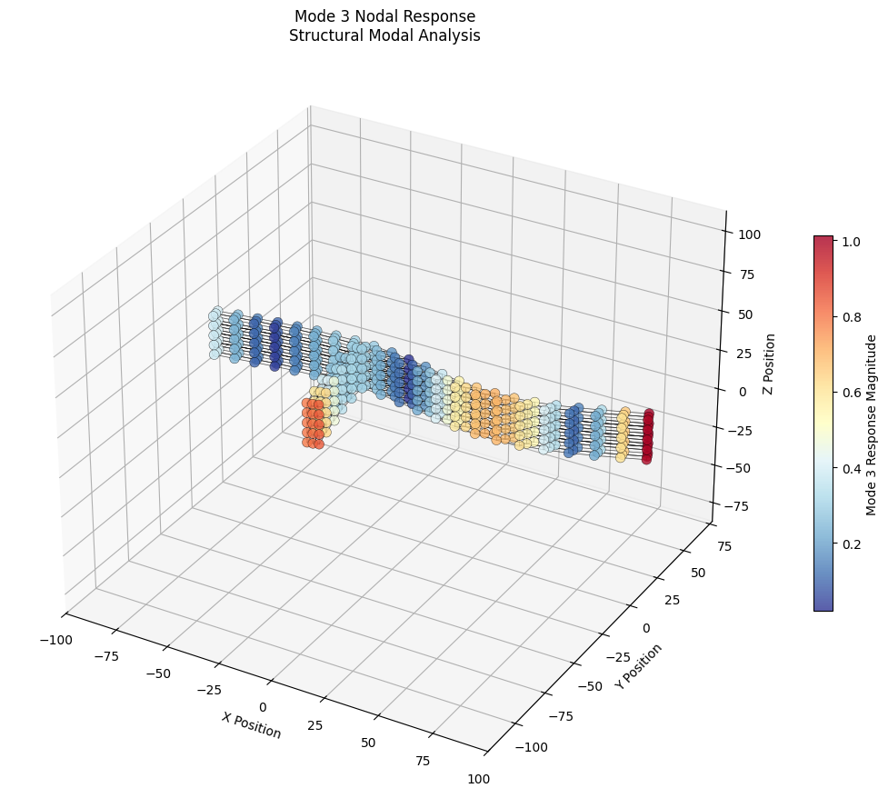

```
Mode 3 visualization completed
Color map shows response amplitude distribution across structure
This mode shape will influence optimal sensor placement strategy
```

```python
# Plot nodal response for mode 3
mode_number_1 = 3

axes_handle_1 = plot_nodal_response(node_layout, mode_shapes, resp_dof, elements, mode_number_1)

plt.title(f'Mode {mode_number_1} Nodal Response\nStructural Modal Analysis')
plt.tight_layout()
plt.show()

print(f"\nMode {mode_number_1} visualization completed")
print(f"Color map shows response amplitude distribution across structure")
print(f"This mode shape will influence optimal sensor placement strategy")
```

## Step 3: Plot Nodal Response (Mode 10)

Visualize the nodal response for mode 10 to compare with mode 3 and understand higher-order modal characteristics.

**Higher-Order Modes**:

- **Increased complexity**: More variation across structure
- **Local effects**: Higher spatial frequency content
- **Sensor requirements**: May need different optimal locations

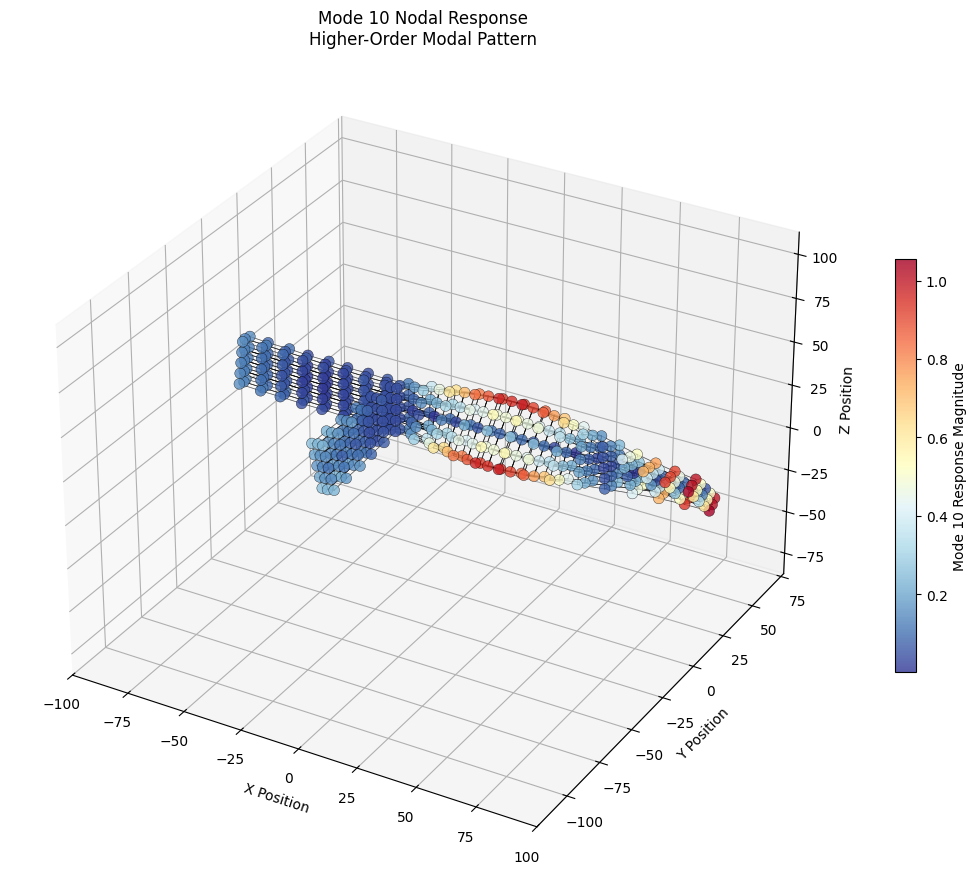

```
Mode 10 visualization completed
Higher-order modes show increased spatial complexity
Comparison with Mode 3 reveals different response patterns
```

```python
# Plot nodal response for mode 10
mode_number_2 = 10

axes_handle_2 = plot_nodal_response(node_layout, mode_shapes, resp_dof, elements, mode_number_2)

plt.title(f'Mode {mode_number_2} Nodal Response\nHigher-Order Modal Pattern')
plt.tight_layout()
plt.show()

print(f"\nMode {mode_number_2} visualization completed")
print(f"Higher-order modes show increased spatial complexity")
print(f"Comparison with Mode {mode_number_1} reveals different response patterns")
```

## Step 4: OSP Fisher Information EIV

**Fisher Information Method**:

- **Objective**: Maximize det(Fisher Information Matrix)
- **Algorithm**: Effective Independence (EI) - greedy sequential selection
- **Criterion**: Maximizes information content for modal parameter estimation
- **Advantage**: Theoretically optimal for parameter estimation accuracy

```python
# OSP using Fisher Information Matrix with Effective Independence method
num_sensors_fisher = 12

[optimal_list_fisher, det_q] = osp_fisher_info_eiv_shm(num_sensors_fisher, mode_shapes, None)

print(f"Fisher Information EIV optimization completed:")
print(f"  Number of optimal sensors: {num_sensors_fisher}")
print(f"  Determinant of Q matrix: {det_q}")
print(f"  Optimal DOF indices: {optimal_list_fisher}")

# Display sensor statistics
print(f"\nOptimal sensor DOFs (Fisher Information):")
for i, dof in enumerate(optimal_list_fisher):
    if dof-1 < len(resp_dof):  # Convert to 0-based indexing
        node_id, direction = resp_dof[dof-1, :]
        print(f"  Sensor {i+1:2d}: DOF {dof:3d} -> Node {node_id:.0f}, Direction {direction:.0f}")
    else:
        print(f"  Sensor {i+1:2d}: DOF {dof:3d} (index out of range)")

print(f"\nFisher Information criterion maximizes modal parameter estimation accuracy")
```

```
Fisher Information EIV optimization completed:
  Number of optimal sensors: 12
  Determinant of Q matrix: 0.04787494165054884
  Optimal DOF indices: [  1  12  71 451 453 458 467 554 751 754 874 878]

Optimal sensor DOFs (Fisher Information):
  Sensor  1: DOF   1 -> Node 1, Direction 1
  Sensor  2: DOF  12 -> Node 12, Direction 1
  Sensor  3: DOF  71 -> Node 71, Direction 1
  Sensor  4: DOF 451 -> Node 31, Direction 2
  Sensor  5: DOF 453 -> Node 33, Direction 2
  Sensor  6: DOF 458 -> Node 38, Direction 2
  Sensor  7: DOF 467 -> Node 47, Direction 2
  Sensor  8: DOF 554 -> Node 134, Direction 2
  Sensor  9: DOF 751 -> Node 331, Direction 2
  Sensor 10: DOF 754 -> Node 334, Direction 2
  Sensor 11: DOF 874 -> Node 34, Direction 3
  Sensor 12: DOF 878 -> Node 38, Direction 3

Fisher Information criterion maximizes modal parameter estimation accuracy
```

## Step 5: Plot Sensors With Mesh (Fisher Information)

Visualize the optimal sensor locations determined by the Fisher Information method overlaid on the structural mesh.

**Visualization Features**:

- **3D wireframe mesh**: Structural geometry
- **Sensor locations**: Red markers at optimal positions
- **Sensor numbering**: Labels for identification
- **Spatial distribution**: Shows coverage across structure

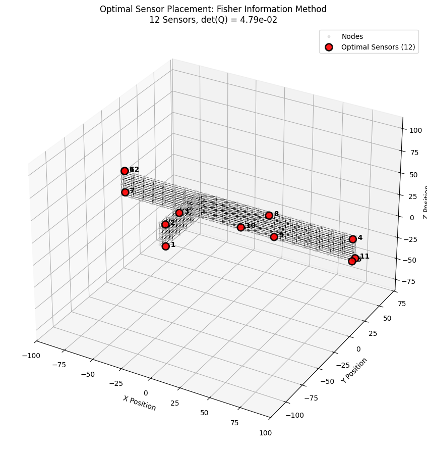

```
Fisher Information sensor placement visualization completed
Red markers show optimal locations for 12 sensors
Sensor distribution maximizes information for modal parameter estimation
```

```python
# Plot optimal sensors on mesh (Fisher Information method)
[axes_handle_fisher_1, axes_handle_fisher_2, sensor_handle_fisher] = plot_sensors_with_mesh(
    elements, node_layout, optimal_list_fisher, resp_dof)

plt.title(f'Optimal Sensor Placement: Fisher Information Method\n{num_sensors_fisher} Sensors, det(Q) = {det_q:.2e}')
plt.tight_layout()
plt.show()

print(f"\nFisher Information sensor placement visualization completed")
print(f"Red markers show optimal locations for {num_sensors_fisher} sensors")
print(f"Sensor distribution maximizes information for modal parameter estimation")
```

## Step 6: OSP Using Maximum Norm

Calculate the 12 optimal DOFs using the Maximum Norm method with linear mode weighting and minimum separation constraints.

**Maximum Norm Method**:

- **Objective**: Maximize weighted norm of modal responses
- **Weighting**: Linear weights (13, 12, 11, ..., 1) favor lower modes
- **Distance constraint**: Minimum separation of 20 units between sensors
- **"Dueling"**: Eliminates sensors that are too close together
- **Advantage**: Ensures good spatial distribution and practical placement

```python
# OSP using Maximum Norm method with constraints
num_sensors_norm = 12
weights = np.array(range(13, 0, -1))  # Linear weights: 13, 12, 11, ..., 1
dueling_distance = 20  # Minimum separation distance

optimal_list_norm = osp_max_norm_shm(
    num_sensors_norm, mode_shapes, weights, dueling_distance, resp_dof, node_layout)

print(f"Maximum Norm optimization completed:")
print(f"  Number of optimal sensors: {num_sensors_norm}")
print(f"  Mode weights: {weights}")
print(f"  Minimum separation distance: {dueling_distance}")
print(f"  Optimal DOF indices: {optimal_list_norm}")

# Display sensor statistics
print(f"\nOptimal sensor DOFs (Maximum Norm):")
for i, dof in enumerate(optimal_list_norm):
    if dof-1 < len(resp_dof):  # Convert to 0-based indexing
        node_id, direction = resp_dof[dof-1, :]
        print(f"  Sensor {i+1:2d}: DOF {dof:3d} -> Node {node_id:.0f}, Direction {direction:.0f}")
    else:
        print(f"  Sensor {i+1:2d}: DOF {dof:3d} (index out of range)")

print(f"\nMaximum Norm method ensures good spatial distribution with distance constraints")
```

```
Maximum Norm optimization completed:
  Number of optimal sensors: 12
  Mode weights: [13 12 11 10  9  8  7  6  5  4  3  2  1]
  Minimum separation distance: 20
  Optimal DOF indices: [451 453 458 467   1  12 546 549 541 554 544 551]

Optimal sensor DOFs (Maximum Norm):
  Sensor  1: DOF 451 -> Node 31, Direction 2
  Sensor  2: DOF 453 -> Node 33, Direction 2
  Sensor  3: DOF 458 -> Node 38, Direction 2
  Sensor  4: DOF 467 -> Node 47, Direction 2
  Sensor  5: DOF   1 -> Node 1, Direction 1
  Sensor  6: DOF  12 -> Node 12, Direction 1
  Sensor  7: DOF 546 -> Node 126, Direction 2
  Sensor  8: DOF 549 -> Node 129, Direction 2
  Sensor  9: DOF 541 -> Node 121, Direction 2
  Sensor 10: DOF 554 -> Node 134, Direction 2
  Sensor 11: DOF 544 -> Node 124, Direction 2
  Sensor 12: DOF 551 -> Node 131, Direction 2

Maximum Norm method ensures good spatial distribution with distance constraints
```

## Step 7: Plot Sensors With Mesh (Maximum Norm)

Visualize the optimal sensor locations determined by the Maximum Norm method overlaid on the structural mesh.

**Comparison with Fisher Information**:

- **Different distribution**: May show different spatial patterns
- **Distance constraints**: Enforced minimum separation
- **Mode weighting effects**: Lower modes have higher influence
- **Practical considerations**: Better for real-world sensor deployment

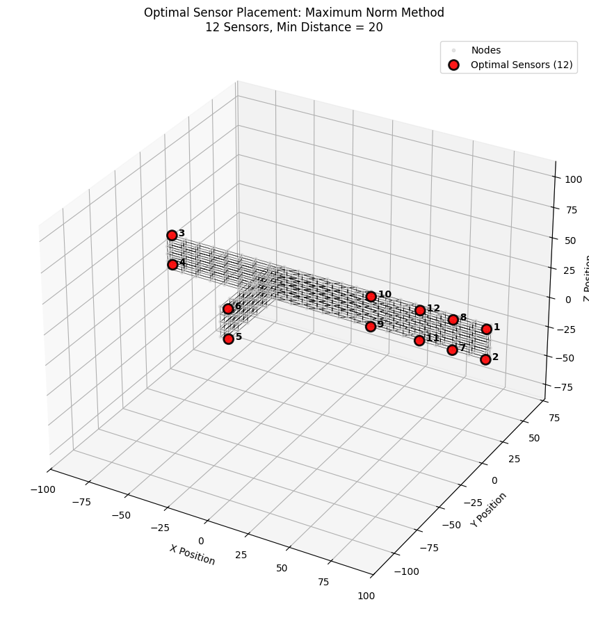

```
Maximum Norm sensor placement visualization completed
Red markers show optimal locations for 12 sensors
Sensor distribution balances modal observability with practical constraints
```

```python
# Plot optimal sensors on mesh (Maximum Norm method)
[axes_handle_norm_1, axes_handle_norm_2, sensor_handle_norm] = plot_sensors_with_mesh(
    elements, node_layout, optimal_list_norm, resp_dof)

plt.title(f'Optimal Sensor Placement: Maximum Norm Method\n{num_sensors_norm} Sensors, Min Distance = {dueling_distance}')
plt.tight_layout()
plt.show()

print(f"\nMaximum Norm sensor placement visualization completed")
print(f"Red markers show optimal locations for {num_sensors_norm} sensors")
print(f"Sensor distribution balances modal observability with practical constraints")
```

## Analysis Summary

This LADPackage optimal sensor placement demo demonstrates two fundamental approaches for designing sensor networks in structural health monitoring:

### Key Results:

1. **Modal Visualization**: Successfully visualized mode shapes 3 and 10 showing different spatial complexity
2. **Fisher Information Method**: Determined 12 optimal sensors maximizing modal parameter estimation accuracy
3. **Maximum Norm Method**: Computed 12 optimal sensors with spatial distribution constraints and mode weighting

### Method Comparison:

[output not shown]

### SHM System Design Guidelines:

1. **Modal coverage**: Ensure sensors can observe critical modes
2. **Spatial distribution**: Balance coverage with installation constraints
3. **Mode weighting**: Prioritize modes based on damage sensitivity
4. **Physical constraints**: Consider accessibility and wiring requirements

**Note**: This analysis provides the foundation for designing effective SHM sensor networks using modal-based optimization criteria.